# CMF_BS_Semak

## Black-Scholes-Merton model. Part 1.

### Предположения модели

В моделе Блэка-Шоулза предполагается, что на рынке есть безрисковый актив (Bond) и как минимум один актив с риском (Stock). (B, S)-рынок.

Предположения о рынке:

- **No arbitrage** (не существует стратегии, которая бы давала прибыль без риска принести убытки).
- Можно занимать поцию с **любым номиналом** по все доступным активам. Включаю отрицательные (long / short selling, borrow / lend) и дробные номиналы.
- **Frictionless market**. Принебрегаем стоимостью транзаций и Bid/Ask spread.

Активы ( B, S ):

- Risk-free rate: **r = const**.
- Движение рыночной цены S - **геометрическое броуновское движение** с постоянными параметрами drift и volatility.
- В классическом варианте по underlying активу нет начисления дивидентов. Но модель легко обобщается на случай актива с дивидентами. Это необходимо для, например, для FX options.

### Уровнение для цены опциона

$$ \frac{\partial C}{\partial t} + \frac{1}{2}\sigma^2 S^2 \frac{\partial^2 C}{\partial S^2} + rS\frac{\partial C}{\partial S} - rC = 0 $$ PDE, not SDE (!)

### Формула ( $q \ne 0$)

Формула Блэка-Шоулза для Европейского call-опциона:

$$ C(S, K, \tau, r, q, \sigma) = N( d_+ ) S e^{ -q \tau} - N( d_- ) K e^{ -r \tau } $$

для put-опциона:

$$ P(S, K, \tau, r, q, \sigma) = K e^{-r \tau } N( -d_{-} ) - S_0 e^{ - q \tau } N( -d_{+} ) $$

где: $$ \tau = T - t $$ .

$$ d_{+} = \frac{ \log{ \frac{S}{K} } + (r-q + \frac{ \sigma^{2} }{2} \tau ) }{ \sigma \sqrt{ \tau } } = d_{1} $$
и

$$ d_{-} = d_{+} - \sigma \sqrt{ \tau } = \frac{ \log{ \frac{S}{K} } + (r-q - \frac{ \sigma^{2} }{2} \tau ) }{ \sigma \sqrt{ \tau } } = d_{2} $$

$N(z) = \Phi(z) = \frac{1}{\sqrt{2 \pi}} \int_{-\infty}^{z} e^{-\frac{ x^{2}}{2} } dx$ это функция распределения для стандартного нормального (гаусовского) распределения.

Плотность распределения: $N'(z) = \phi(z) = \frac{1}{\sqrt{2 \pi}} e^{-\frac{ x^{2}}{2}}$.

```python
import numpy as np
import scipy as sp
from scipy import stats
import math as m

import matplotlib.pyplot as plt
%matplotlib inline
from time import time
```

```python
def N(x):
    return stats.norm.cdf(x, 0.0, 1.0)

def NPrime(x):
    return stats.norm.pdf(x, 0.0, 1.0)

def bsm_d1(S, K, T, r, q, sigma):
    return (np.log(S / K) + (r - q + 0.5 * sigma ** 2) * T) / (sigma * m.sqrt(T))

def bsm_d2(S, K, T, r, q, sigma):
    return (np.log(S / K) + (r - q - 0.5 * sigma ** 2) * T) / (sigma * m.sqrt(T))

def bsm_pv(isCall, S, K, T, r, q, sigma):
    d1 = bsm_d1(S, K, T, r, q, sigma)
    d2 = bsm_d2(S, K, T, r, q, sigma)
    if isCall:
        return S * N(d1) * m.exp(-q * T) - K * m.exp(-r * T) * N(d2)
    else:
        return K * N(-d2) * m.exp(-r * T)  - S * m.exp(-q * T) * N(-d1)

def bsm_delta(isCall, S, K, T, r, q, sigma):
    d1 = bsm_d1(S, K, T, r, q, sigma)
    if isCall:
        return N(d1) * m.exp(-q * T)
    else:
        return -N(-d1) * m.exp(-q * T)

def bsm_gamma(isCall, S, K, T, r, q, sigma):
    d2 = bsm_d1(S, K, T, r, q, sigma)
    return NPrime(d2) * m.exp(-q * T) / (S * sigma * m.sqrt(T))

def bsm_vega(isCall, S, K, T, r, q, sigma):
    d1 = bsm_d1(S, K, T, r, q, sigma)
    return S * NPrime(d1) * m.sqrt(T)
```

```python
def call_payoff(K, S):
    return np.maximum(S-K, 0)
```

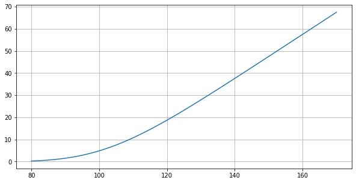

```python
K = 110
r = 0.07
sigma = 0.15
x = np.linspace(K-30, K+60, num=100)
#
f, ax = plt.subplots(figsize=(10,5))
ax.grid(True)
ax.plot(x, bsm_pv(True, S=x, K=K, T=1, r=r, q=0, sigma=sigma ))
```

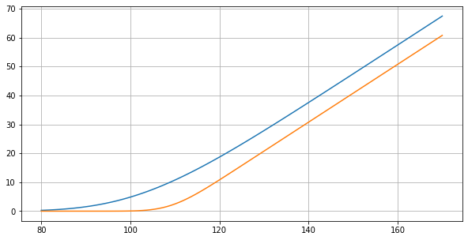

```python
ax.plot(x, bsm_pv(True, S=x, K=K, T=0.1, r=r, q=0, sigma=sigma ))
f
```

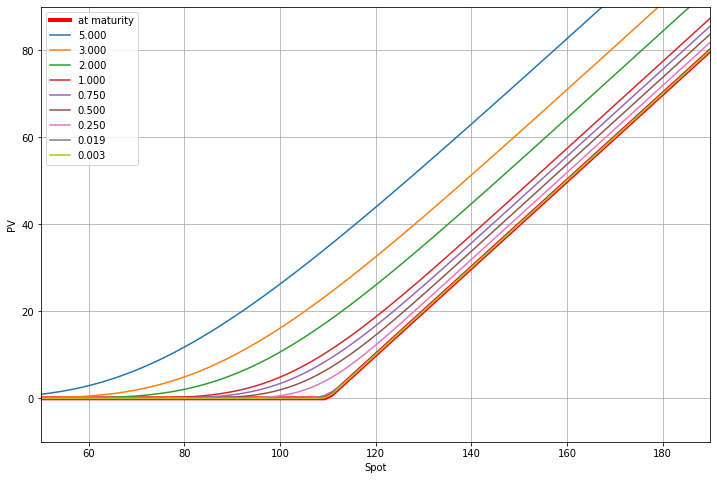

```python
Ts = [5, 3, 2, 1, 0.75, 0.5, 0.25, 1./52., 1./365.]

x = np.linspace(50, K+80, num=100)
f, ax = plt.subplots(figsize=(12,8))
ax.grid(True)
plt.plot(x, call_payoff(K, x), 'r', linewidth=4)
for T in Ts:
    ax.plot(x, bsm_pv(True, S=x, K=K, T=T, r=r, q=0, sigma=sigma ))
plt.legend(['at maturity'] + ['{:.3f}'.format(t) for t in Ts], loc = "upper left")
axes = plt.gca()
axes.set_xlim([min(x),max(x)]); axes.set_ylim([-10,90]);
axes.set_xlabel('Spot'); axes.set_ylabel('PV');
```

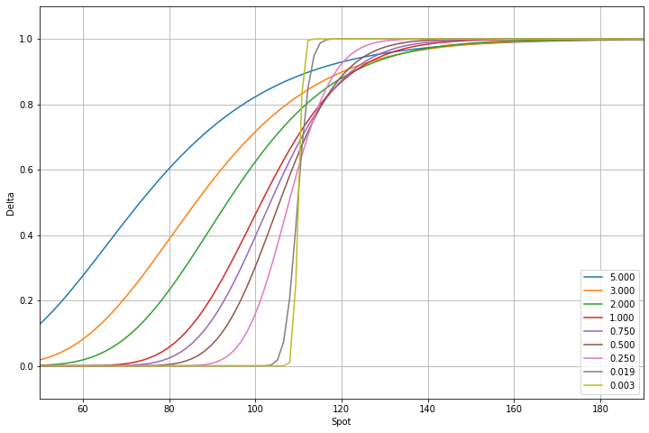

```python
Ts = [5, 3, 2, 1, 0.75, 0.5, 0.25, 1./52., 1./365.]

x = np.linspace(50, K+80, num=100)
f, ax = plt.subplots(figsize=(12,8))
ax.grid(True)
for T in Ts:
    ax.plot(x, bsm_delta(True, S=x, K=K, T=T, r=r, q=0, sigma=sigma ))
plt.legend(['{:.3f}'.format(t) for t in Ts], loc = "lower right")
axes = plt.gca()
axes.set_xlim([min(x),max(x)]); axes.set_ylim([-0.1,1.1]);
axes.set_xlabel('Spot'); axes.set_ylabel('Delta');
```

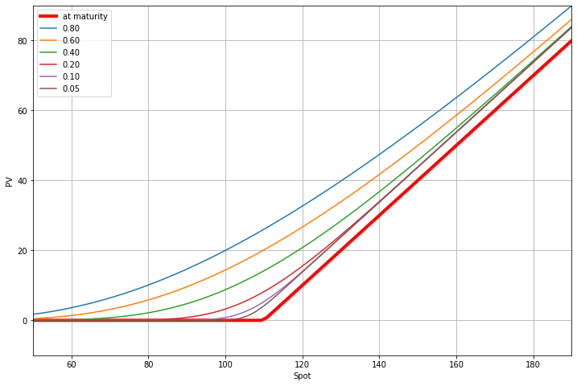

```python
T = 0.5
sigmas = [0.8, 0.6, 0.4, 0.2, 0.1, 0.05]

x = np.linspace(50, K+80, num=100)
f, ax = plt.subplots(figsize=(12,8))
ax.grid(True)
plt.plot(x, call_payoff(K, x), 'r', linewidth=4)
for sigma in sigmas:
    ax.plot(x, bsm_pv(True, S=x, K=K, T=T, r=r, q=0, sigma=sigma ))
plt.legend(['at maturity'] + ['{:.2f}'.format(s) for s in sigmas], loc = "upper left")
axes = plt.gca()
axes.set_xlim([min(x),max(x)]); axes.set_ylim([-10,90]);
axes.set_xlabel('Spot'); axes.set_ylabel('PV');
```

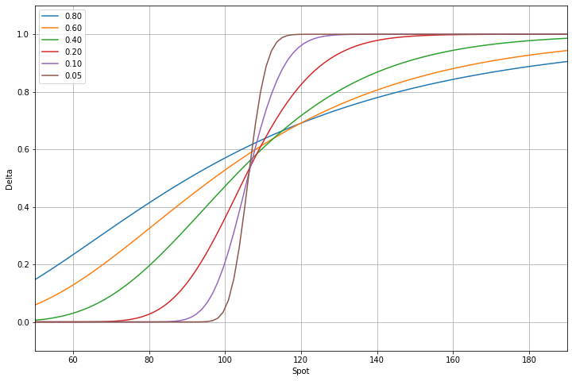

```python
T = 0.5
sigmas = [0.8, 0.6, 0.4, 0.2, 0.1, 0.05]

x = np.linspace(50, K+80, num=100)
f, ax = plt.subplots(figsize=(12,8))
ax.grid(True)
#plt.plot(x, call_payoff(K, x), 'r', linewidth=4)
for sigma in sigmas:
    ax.plot(x, bsm_delta(True, S=x, K=K, T=T, r=r, q=0, sigma=sigma ))
plt.legend(['{:.2f}'.format(s) for s in sigmas], loc = "upper left")
axes = plt.gca()
axes.set_xlim([min(x),max(x)]); axes.set_ylim([-0.1,1.1]);
axes.set_xlabel('Spot'); axes.set_ylabel('Delta');
```

## Black-Scholes-Merton model. Part 2.

$ C_0 = E\left[ e^{-rT} max(0, S_T - K) \right] $

$S(t) = S(t-\Delta t) \exp(r t - \frac{1}{2} \sigma^2 t + \sigma W_t )$

```python
S0 = 80.; K = 85.; T = 1.0; r = 0.05; # q = 0.0;
sigma = 0.2
```

```python
ref_pv = 5.98824380
```

```python
def mc_euro_call_pv_with_paths0(S0, K, T, r, sigma, M, I):
    # Simulating I paths with M time steps
    S = np.zeros((M + 1, I))
    S[0] = S0
    dt = float(T) / M
    for t in range(1, M + 1):
        z = np.random.standard_normal(I)
        S[t] = S[t - 1] * np.exp((r - 0.5 * sigma ** 2) * dt + sigma * m.sqrt(dt) * z)

    # PV is extected discounted payoff
    C = np.sum(m.exp(-r * T) * np.maximum(S[-1] - K, 0)) / I
    return C, S
```

```python
# Parameters
M = 360; I = 50000
```

```python
np.random.seed(12345)
t0 = time()
C, SPaths = mc_euro_call_pv_with_paths0(S0, K, T, r, sigma, M, I)
calcTime = time() - t0

print( "PV: %.5f, abs diff: %.5f, rel diff:  %.5f" % (C, ref_pv - C, (ref_pv - C)/C) )
print( "Calculation time   %.5f" % calcTime )
```

```
PV: 5.95967, abs diff: 0.02858, rel diff:  0.00480
Calculation time   0.75503
```

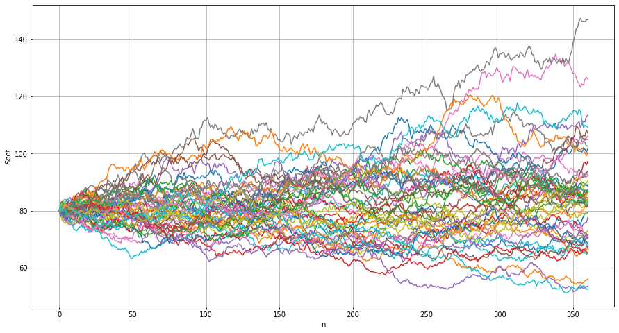

```python
plt.figure(figsize=(15,8))
plt.plot(SPaths[:, :50])
plt.grid(True)
plt.xlabel('n')
plt.ylabel('Spot')
```

```python
def mc_euro_call_pv_no_paths(S0, K, T, r, sigma, I):
    # Simulating I values
    z = np.random.standard_normal(I)
    S = S0 * np.exp((r - 0.5 * sigma ** 2) * T + sigma * m.sqrt(T) * z)

    # payoff
    P = np.maximum(S - K, 0)
    # PV as expected discounted payoff
    C = np.sum( m.exp(-r * T) * P ) / I
    return C, S

np.random.seed(12345)
t0 = time()
C, S = mc_euro_call_pv_no_paths(S0, K, T, r, sigma, I)
calcTime = time() - t0

print( "PV: %.5f, abs diff: %.5f, rel diff:  %.5f" % (C, ref_pv - C, (ref_pv - C)/C) )
print( "Calculation time   %.5f" % calcTime )
```

```
PV: 5.99660, abs diff: -0.00836, rel diff:  -0.00139
Calculation time   0.00500
```

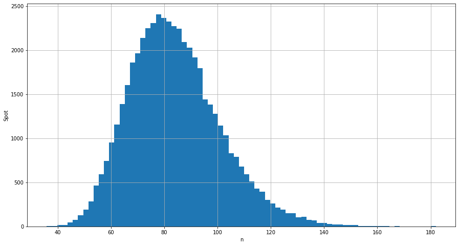

```python
plt.figure(figsize=(15,8))
plt.hist(S, 75)
plt.grid(True)
plt.xlabel('n')
plt.ylabel('Spot')
```

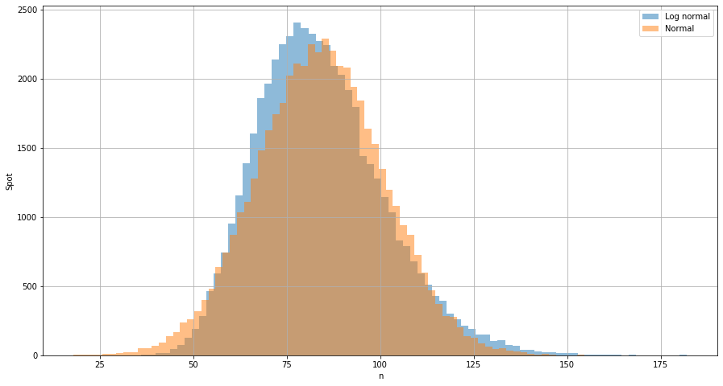

```python
z = np.random.standard_normal(I)
z = z * np.std(S)
z = z + np.mean(S)

plt.figure(figsize=(15,8))
plt.hist(S, 75, alpha=0.5, label='Log normal')
plt.hist(z, 75, alpha=0.5, label='Normal')

plt.legend(loc='upper right')
plt.grid(True)
plt.xlabel('n')
plt.ylabel('Spot')
```

```python
print( "Expected mean: %.5f, mean: %.5f" % (S0 * m.exp(r*T), np.mean(S)) )
print( "Expected std: %.5f, std:  %.5f" % ( S0* m.exp(r*T ) * m.sqrt(m.exp( sigma * sigma *T ) - 1) , np.std(S)) )
# Std formular: https://en.wikipedia.org/wiki/Geometric_Brownian_motion#Properties
```

```
Expected mean: 84.10169, mean: 84.07869
Expected std: 16.98995, std:  16.99925
```

## Homework

Find $ \Delta $ using Monte Carlo method?